# Has children and/or grandchildren

# 1 Description of DataSchema variable

The description of harmonised variables is the following:

- Short name: `child`
- Variable label: `Has children`
- Domain: `Social environment`
- Value type: `categorical`
- Categories:

| **Code** | **Category Label** |
| --- | --- |
| 0 | No |
| 1 | Yes |

- Category missings:

| **Code** | **Category Label** |
| --- | --- |
| 991 | CAPI/interviewer error |
| 992 | Impute |
| 993 | Disable to measure |
| 994 | Not attempt/not done |
| 995 | Does not answer |
| 996 | Not applicable |
| 997 | Refuse |
| 998 | Do not know |
| 999 | Missing |

- Short name: `grchild`
- Variable label: `Has grandchildren`
- Domain: `Social environment`
- Value type: `categorical`
- Categories:

| **Code** | **Category Label** |
| --- | --- |
| 0 | No |
| 1 | Yes |

- Category missings:

| **Code** | **Category Label** |
| --- | --- |
| 991 | CAPI/interviewer error |
| 992 | Impute |
| 993 | Disable to measure |
| 994 | Not attempt/not done |
| 995 | Does not answer |
| 996 | Not applicable |
| 997 | Refuse |
| 998 | Do not know |
| 999 | Missing |

# 2 Data process

## 2.1 England

### 2.1.1 Wave 1

#### 2.1.1.1 Study-specific variable description

The study-specific variable elected to be harmonised is:

- Name: `scchd` *from ‘ELSA.wave_1_core_data_v3’*
- Label: `do you have any children`
- Categories:
  - `1 = Yes`
  - `2 = No`
- Missings:
  - `-9 = Not answered`
  - `-1 = Item not applicable`
- Name: `ngrandch` *from ‘wave_1_ifs_derived_variables’*
- Label: `Number of grandchildren or great-grandchildren inside or outside the household?`
- Missings:
  - `-9 = Refuse`
  - `-8 = Don't Know`
  - `-2 = Not asked`
- Description:

SCCHD

| Sample size | Missing values |
| --- | --- |
| 12099 | 1255 |

Category

|  | 1 | 2 |
| --- | --- | --- |
| Frequency | 9390.00 | 1454.00 |
| Percentage | 77.61 | 12.02 |

Type of missing

|  | -9 | -1 | NA |
| --- | --- | --- | --- |
| Frequency | 147.00 | 1108.00 | 0 |
| Percentage | 1.21 | 9.16 | 0 |

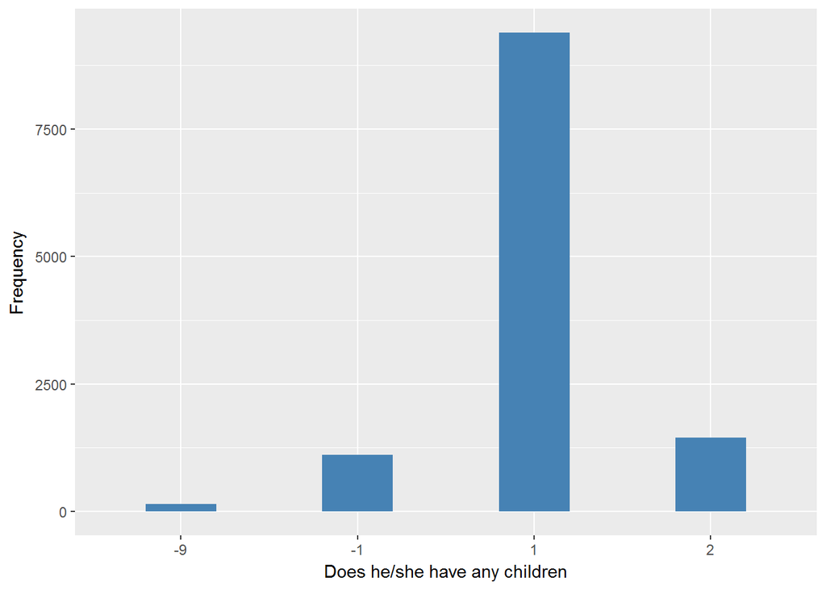

NGRANDCH

| Sample size | Missing values |
| --- | --- |
| 12099 | 40 |

Values

|  | No-missings | -9 | -8 | -2 | NA |
| --- | --- | --- | --- | --- | --- |
| Frequency | 12059.00 | 3.00 | 37.00 | 0 | 0 |
| Percentage | 99.67 | 0.02 | 0.31 | 0 | 0 |

Summary

| Min. | 1st Qu. | Median | Mean | 3rd Qu. | Max. |
| --- | --- | --- | --- | --- | --- |
| 0 | 0 | 2 | 2.969 | 4 | 65 |

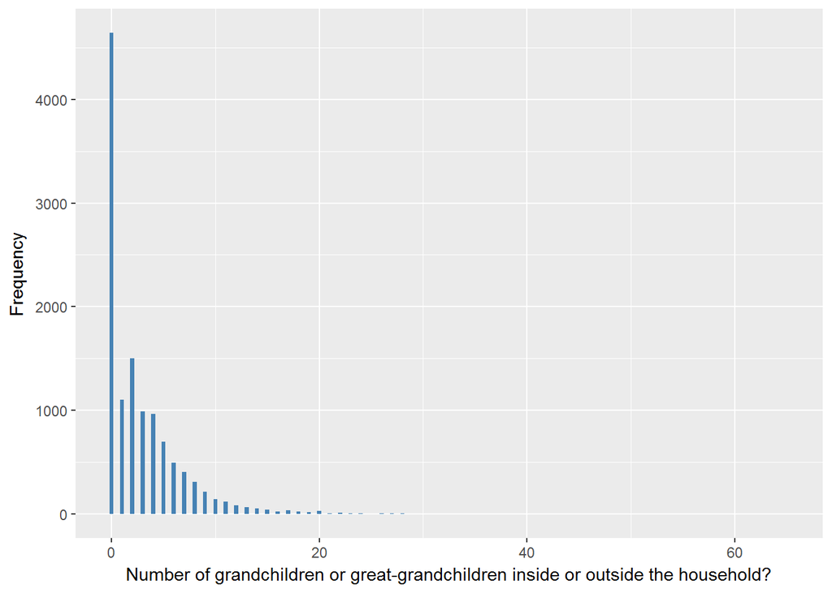

#### 2.1.1.2 Harmonisation algorithm

To compute the harmonize variable from the study-specific variable it has to be recoded as follows:

- `CHILDREN:`
- `1 into 1`
- `2 into 0`
- `Missings: -9 into 995; -1 into 996`
- `GRANDCHILDREN:`
- `0 INTO 0`
- `1:hi into 1`
- `Missings: -9 into 997; -8 into 998; -2 into 994`
- `NA into 999`

**R script:**

```r
ELSA_ds_w1 <- tibble(id = ELSA_w1_child$id)
ELSA_ds_w1$child <- car::recode(as.vector(ELSA_w1_child$scchd), "1='1'; 2='0'; -9='995'; -1='996'; NA='999'")
ELSA_ds_w1$child <- labelled(ELSA_ds_w1$child, labels = c(No = 0, Yes = 1, Missing = 999,
    `Do not know` = 998, Refuse = 997, `Not applicable` = 996, `Don't answer` = 995,
    `Not attempt/not done/not yet recorded` = 994, `Disable to measure` = 993,
    Impute = 992, `CAPI/interviewer error` = 991))

ELSA_ds_w1$grchild <- car::recode(as.vector(ELSA_w1_grchild$ngrandch), "0='0'; -9='997'; -8='998'; -2='994'; NA='999'; 1:hi='1'")
ELSA_ds_w1$grchild <- labelled(ELSA_ds_w1$grchild, labels = c(No = 0, Yes = 1,
    Missing = 999, `Do not know` = 998, Refuse = 997, `Not applicable` = 996,
    `Don't answer` = 995, `Not attempt/not done/not yet recorded` = 994, `Disable to measure` = 993,
    Impute = 992, `CAPI/interviewer error` = 991))
```

#### 2.1.1.3 Statistical description of the new harmonised variable

Children

| Sample size | Missing values |
| --- | --- |
| 12099 | 1255 |

Category

|  | 0 | 1 |
| --- | --- | --- |
| Frequency | 1454.00 | 9390.00 |
| Percentage | 12.02 | 77.61 |

Type of missing

|  | 991 | 992 | 993 | 994 | 995 | 996 | 997 | 998 | 999 | NA |
| --- | --- | --- | --- | --- | --- | --- | --- | --- | --- | --- |
| Frequency | 0 | 0 | 0 | 0 | 147.00 | 1108.00 | 0 | 0 | 0 | 0 |
| Percentage | 0 | 0 | 0 | 0 | 1.21 | 9.16 | 0 | 0 | 0 | 0 |

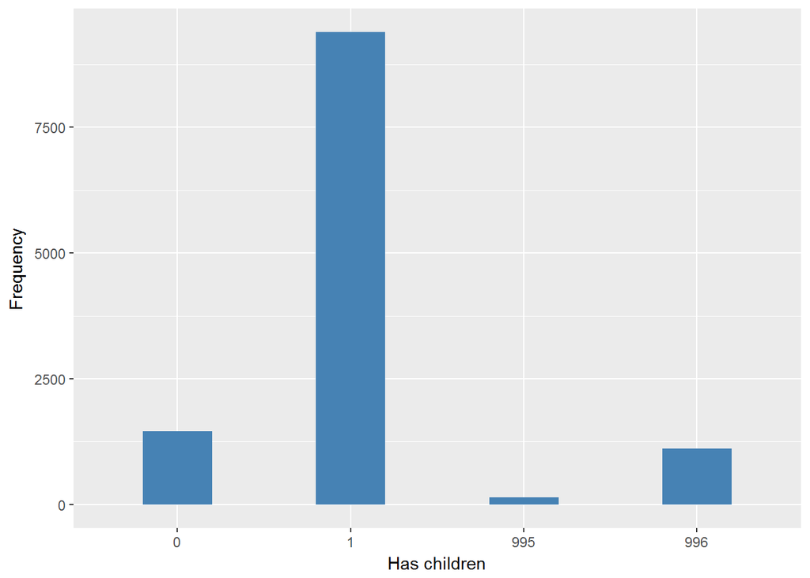

Grandchildren

| Sample size | Missing values |
| --- | --- |
| 12099 | 40 |

Category

|  | 0 | 1 |
| --- | --- | --- |
| Frequency | 4641.00 | 7418.00 |
| Percentage | 38.36 | 61.31 |

Type of missing

|  | 991 | 992 | 993 | 994 | 995 | 996 | 997 | 998 | 999 | NA |
| --- | --- | --- | --- | --- | --- | --- | --- | --- | --- | --- |
| Frequency | 0 | 0 | 0 | 0 | 0 | 0 | 3.00 | 37.00 | 0 | 0 |
| Percentage | 0 | 0 | 0 | 0 | 0 | 0 | 0.02 | 0.31 | 0 | 0 |

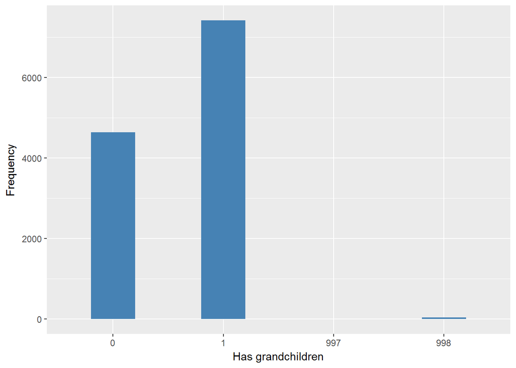

#### 2.1.1.4 Validation

|  | 2->0 | 1 | -9->995 | -1->996 |
| --- | --- | --- | --- | --- |
| BeforeH1 | 1454 | 9390 | 147 | 1108 |
| AfterH1 | 1454 | 9390 | 147 | 1108 |

|  | 2->0 | 1 | -9->997 | -8->998 |
| --- | --- | --- | --- | --- |
| BeforeH2 | 4641 | 7418 | 3 | 37 |
| AfterH2 | 4641 | 7418 | 3 | 37 |

### 2.1.2 Wave 2

#### 2.1.2.1 Study-specific variable description

The study-specific variable elected to be harmonised is:

- Name: `scchd`
- Label: `Whether the respondent has any children`
- Categories:
  - `1 = Yes`
  - `2 = No`
- Missings:
  - `-9 = Not answered`
  - `-1 = Item not applicable`
- Name: `DiGran`
- Label: `Whether respondent has any grandchildren/greatgrandchildren`
- Categories:
  - `1 = Yes`
  - `2 = No`
- Missings:
  - `-9 = Refusal`
  - `-8 = Don't Know`
  - `-1 = Not applicable`
- Description:

SCCHD

| Sample size | Missing values |
| --- | --- |
| 9432 | 1261 |

Category

|  | 1 | 2 |
| --- | --- | --- |
| Frequency | 7137.00 | 1034.00 |
| Percentage | 75.67 | 10.96 |

Type of missing

|  | -9 | -1 | NA |
| --- | --- | --- | --- |
| Frequency | 189 | 1072.00 | 0 |
| Percentage | 2 | 11.37 | 0 |

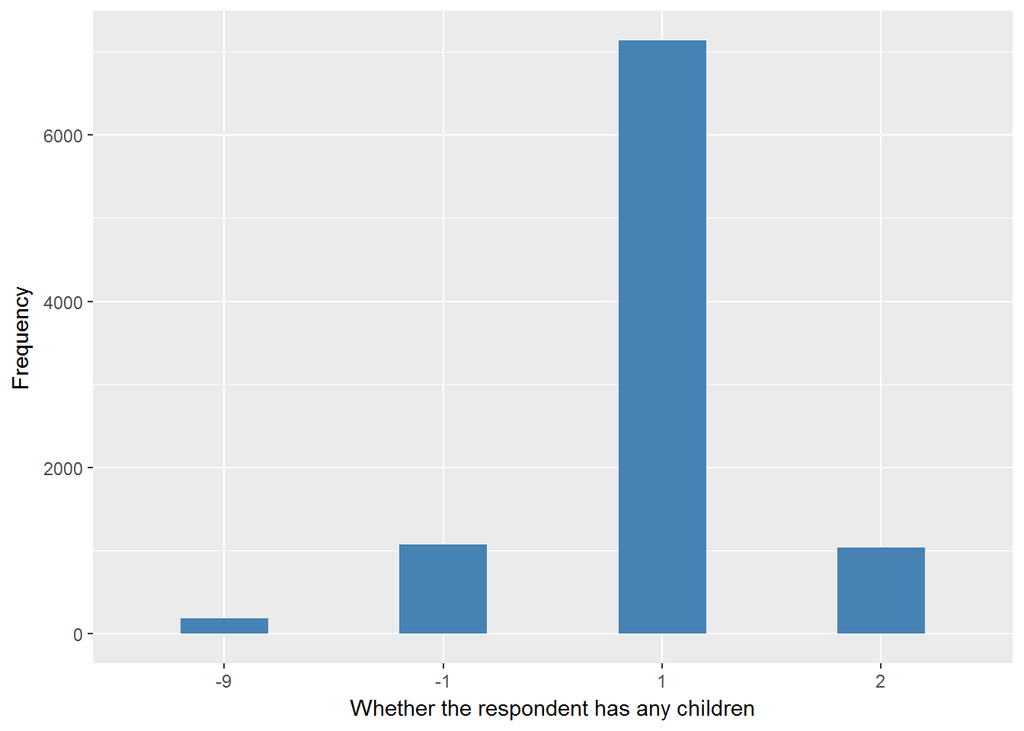

DIGRAN

| Sample size | Missing values |
| --- | --- |
| 9432 | 5650 |

Category

|  | 1 | 2 |
| --- | --- | --- |
| Frequency | 581.00 | 3201.00 |
| Percentage | 6.16 | 33.94 |

Type of missing

|  | -9 | -8 | -1 | NA |
| --- | --- | --- | --- | --- |
| Frequency | 0 | 12.00 | 5638.00 | 0 |
| Percentage | 0 | 0.13 | 59.78 | 0 |

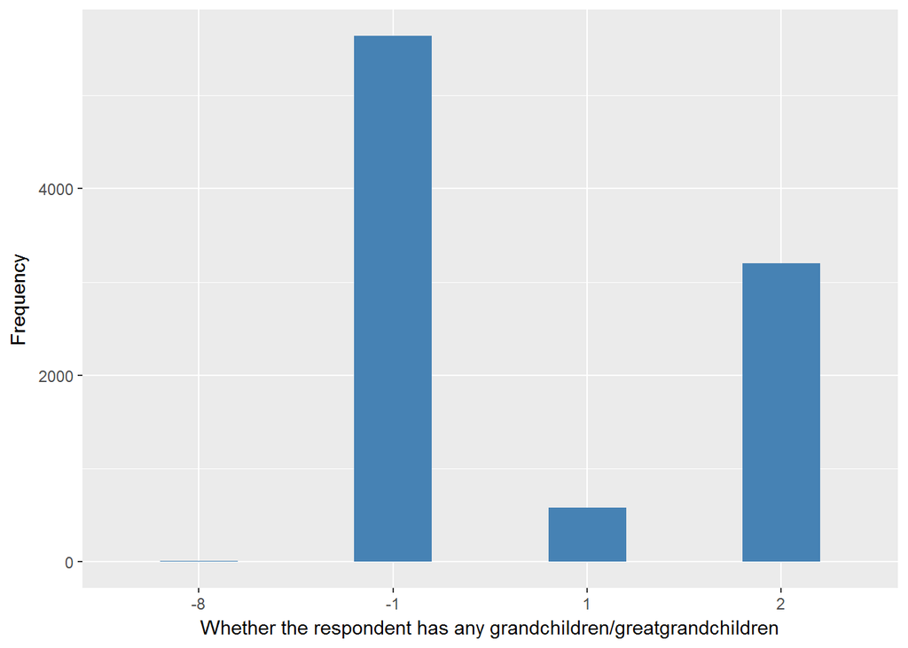

#### 2.1.2.2 Harmonisation algorithm

To compute the harmonize variable from the study-specific variable it has to be recoded as follows:

- `1 into 1`
- `2 into 0`
- `Missings for CHILD: -9 into 995; -1 into 996`
- `Missings for GRCHILD: -9 into 997; -8 into 998; -1 into 996`
- `NA into 999`

**R script:**

```r
ELSA_ds_w2 <- tibble(id = ELSA_w2_child$id)
ELSA_ds_w2$child <- car::recode(as.vector(ELSA_w2_child$scchd), "1='1'; 2='0'; -9='995'; -1='996'; NA='999'")
ELSA_ds_w2$child <- labelled(ELSA_ds_w2$child, labels = c(No = 0, Yes = 1, Missing = 999,
    `Do not know` = 998, Refuse = 997, `Not applicable` = 996, `Don't answer` = 995,
    `Not attempt/not done/not yet recorded` = 994, `Disable to measure` = 993,
    Impute = 992, `CAPI/interviewer error` = 991))

ELSA_ds_w2$grchild <- car::recode(as.vector(ELSA_w2_child$DiGran), "1='1'; 2='0'; -9='997'; -8='998'; -1='996'; NA='999'")
ELSA_ds_w2$grchild <- labelled(ELSA_ds_w2$grchild, labels = c(No = 0, Yes = 1,
    Missing = 999, `Do not know` = 998, Refuse = 997, `Not applicable` = 996,
    `Don't answer` = 995, `Not attempt/not done/not yet recorded` = 994, `Disable to measure` = 993,
    Impute = 992, `CAPI/interviewer error` = 991))
```

#### 2.1.2.3 Statistical description of the new harmonised variable

Children

| Sample size | Missing values |
| --- | --- |
| 9432 | 1261 |

Category

|  | 0 | 1 |
| --- | --- | --- |
| Frequency | 1034.00 | 7137.00 |
| Percentage | 10.96 | 75.67 |

Type of missing

|  | 991 | 992 | 993 | 994 | 995 | 996 | 997 | 998 | 999 | NA |
| --- | --- | --- | --- | --- | --- | --- | --- | --- | --- | --- |
| Frequency | 0 | 0 | 0 | 0 | 189 | 1072.00 | 0 | 0 | 0 | 0 |
| Percentage | 0 | 0 | 0 | 0 | 2 | 11.37 | 0 | 0 | 0 | 0 |

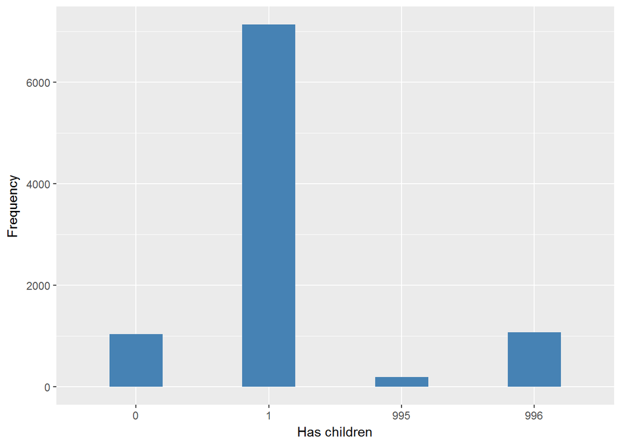

Grandchildren

| Sample size | Missing values |
| --- | --- |
| 9432 | 5650 |

Category

|  | 0 | 1 |
| --- | --- | --- |
| Frequency | 3201.00 | 581.00 |
| Percentage | 33.94 | 6.16 |

Type of missing

|  | 991 | 992 | 993 | 994 | 995 | 996 | 997 | 998 | 999 | NA |
| --- | --- | --- | --- | --- | --- | --- | --- | --- | --- | --- |
| Frequency | 0 | 0 | 0 | 0 | 0 | 5638.00 | 0 | 12.00 | 0 | 0 |
| Percentage | 0 | 0 | 0 | 0 | 0 | 59.78 | 0 | 0.13 | 0 | 0 |

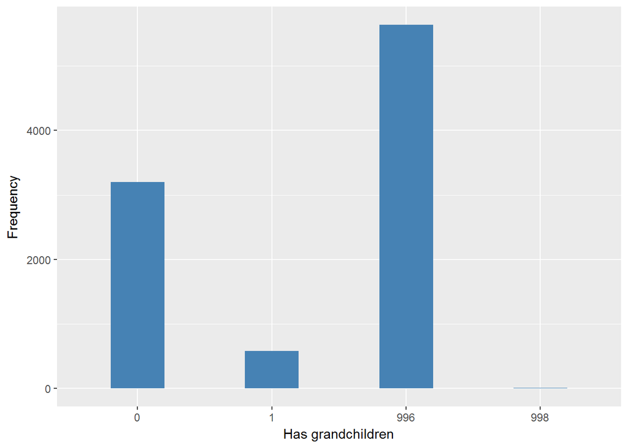

#### 2.1.2.4 Validation

|  | 2->0 | 1 | -9->995 | -1->996 |
| --- | --- | --- | --- | --- |
| BeforeH1 | 1034 | 7137 | 189 | 1072 |
| AfterH1 | 1034 | 7137 | 189 | 1072 |

|  | 2->0 | 1 | -1->996 | -8->998 |
| --- | --- | --- | --- | --- |
| BeforeH2 | 3201 | 581 | 5638 | 12 |
| AfterH2 | 3201 | 581 | 5638 | 12 |

### 2.1.3 Wave 3

#### 2.1.3.1 Study-specific variable description

The study-specific variable elected to be harmonised is:

- Name: `scchd`
- Label: `Whether the respondent has any children`
- Categories:
  - `1 = Yes`
  - `2 = No`
- Missings:
  - `-9 = Not answered`
  - `-8 = Don't know`
  - `-1 = Item not applicable`
- Name: `digran`
- Label: `Whether respondent has any grandchildren/greatgrandchildren`
- Categories:
  - `1 = Yes`
  - `2 = No`
- Missings:
  - `-9 = Refusal`
  - `-8 = Don't Know`
  - `-2 = Schedule not applicable`
  - `-1 = Not applicable`
- Description:

SCCHD

| Sample size | Missing values |
| --- | --- |
| 9771 | 1620 |

Category

|  | 1 | 2 |
| --- | --- | --- |
| Frequency | 7060.00 | 1091.00 |
| Percentage | 72.25 | 11.17 |

Type of missing

|  | -9 | -8 | -1 | NA |
| --- | --- | --- | --- | --- |
| Frequency | 93.00 | 0 | 1527.00 | 0 |
| Percentage | 0.95 | 0 | 15.63 | 0 |

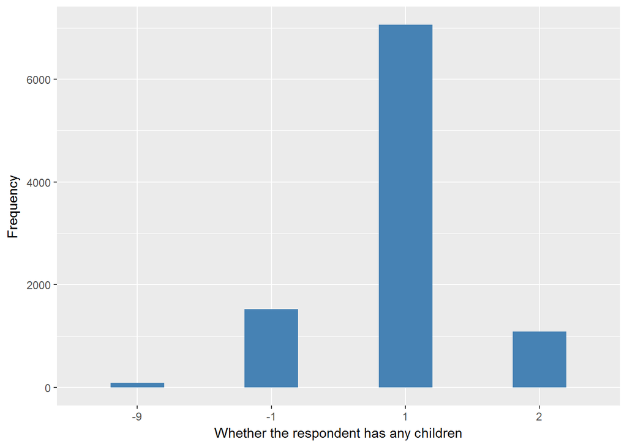

DIGRAN

| Sample size | Missing values |
| --- | --- |
| 9771 | 5247 |

Category

|  | 1 | 2 |
| --- | --- | --- |
| Frequency | 806.00 | 3718.00 |
| Percentage | 8.25 | 38.05 |

Type of missing

|  | -9 | -8 | -2 | -1 | NA |
| --- | --- | --- | --- | --- | --- |
| Frequency | 0 | 16.00 | 0 | 5231.00 | 0 |
| Percentage | 0 | 0.16 | 0 | 53.54 | 0 |

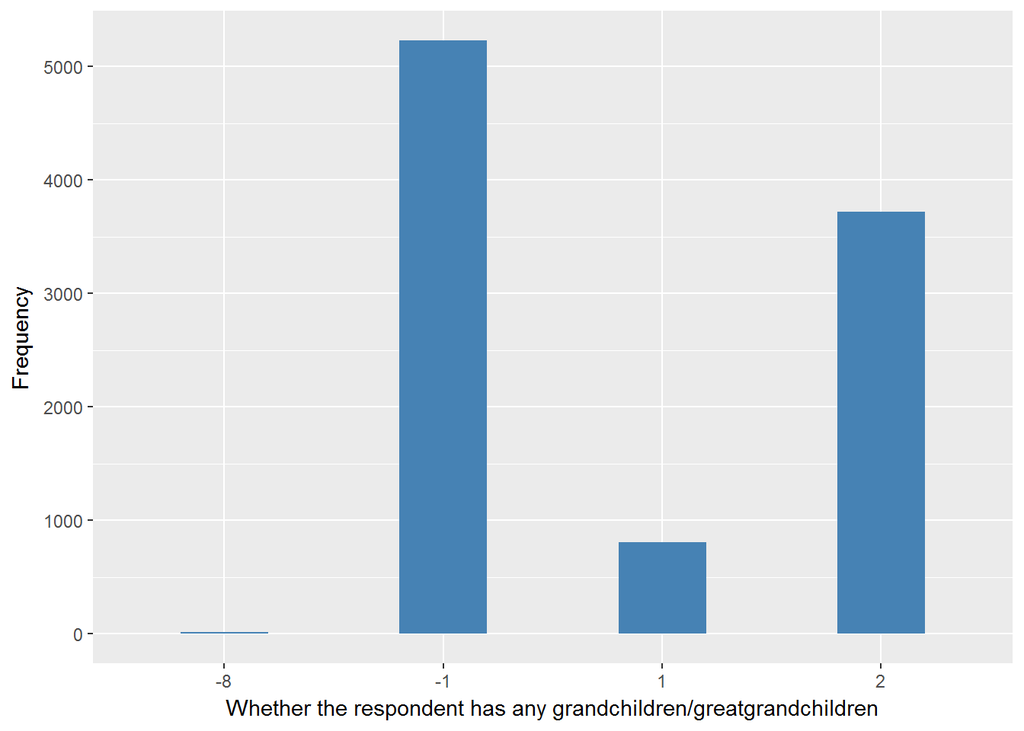

#### 2.1.3.2 Harmonisation algorithm

To recode the harmonize variable from the study-specific variable it has to be recoded as follows:

- `1 into 1`
- `2 into 0`
- `Missings for CHILD: -9 into 995; -8 into 998; -1 into 996`
- `Missings for GRCHILD: -9 into 997; -8 into 998; -2 into 996; -1 into 996`
- `NA into 999`

**R script:**

```r
ELSA_ds_w3 <- tibble(id = ELSA_w3_child$id)
ELSA_ds_w3$child <- car::recode(as.vector(ELSA_w3_child$scchd), "1='1'; 2='0'; -9='995'; -8='998'; -1='996'; NA='999'")
ELSA_ds_w3$child <- labelled(ELSA_ds_w3$child, labels = c(No = 0, Yes = 1, Missing = 999,
    `Do not know` = 998, Refuse = 997, `Not applicable` = 996, `Don't answer` = 995,
    `Not attempt/not done/not yet recorded` = 994, `Disable to measure` = 993,
    Impute = 992, `CAPI/interviewer error` = 991))

ELSA_ds_w3$grchild <- car::recode(as.vector(ELSA_w3_child$digran), "1='1'; 2='0'; -9='997'; -8='998'; -2='996'; -1='996'; NA='999'")
ELSA_ds_w3$grchild <- labelled(ELSA_ds_w3$grchild, labels = c(No = 0, Yes = 1,
    Missing = 999, `Do not know` = 998, Refuse = 997, `Not applicable` = 996,
    `Don't answer` = 995, `Not attempt/not done/not yet recorded` = 994, `Disable to measure` = 993,
    Impute = 992, `CAPI/interviewer error` = 991))
```

#### 2.1.3.3 Statistical description of the new harmonised variable

Children

| Sample size | Missing values |
| --- | --- |
| 9771 | 1620 |

Category

|  | 0 | 1 |
| --- | --- | --- |
| Frequency | 1091.00 | 7060.00 |
| Percentage | 11.17 | 72.25 |

Type of missing

|  | 991 | 992 | 993 | 994 | 995 | 996 | 997 | 998 | 999 | NA |
| --- | --- | --- | --- | --- | --- | --- | --- | --- | --- | --- |
| Frequency | 0 | 0 | 0 | 0 | 93.00 | 1527.00 | 0 | 0 | 0 | 0 |
| Percentage | 0 | 0 | 0 | 0 | 0.95 | 15.63 | 0 | 0 | 0 | 0 |

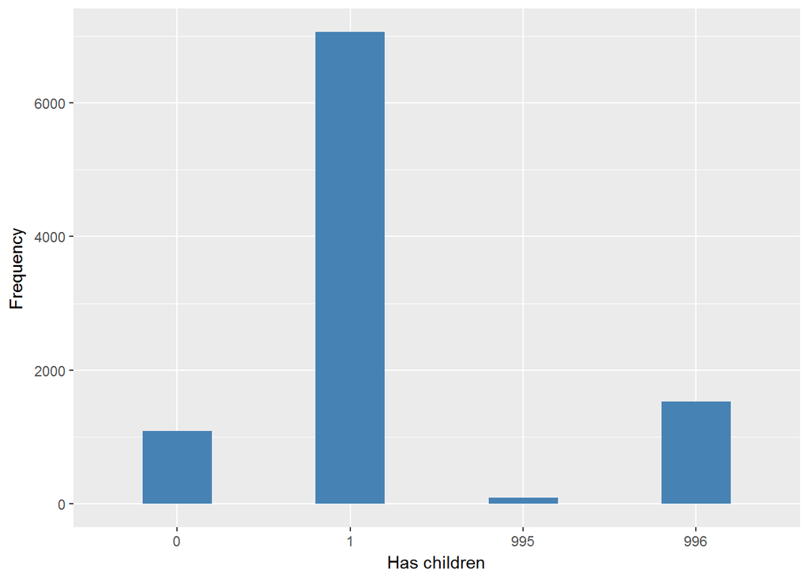

Grandchildren

| Sample size | Missing values |
| --- | --- |
| 9771 | 5247 |

Category

|  | 0 | 1 |
| --- | --- | --- |
| Frequency | 3718.00 | 806.00 |
| Percentage | 38.05 | 8.25 |

Type of missing

|  | 991 | 992 | 993 | 994 | 995 | 996 | 997 | 998 | 999 | NA |
| --- | --- | --- | --- | --- | --- | --- | --- | --- | --- | --- |
| Frequency | 0 | 0 | 0 | 0 | 0 | 5231.00 | 0 | 16.00 | 0 | 0 |
| Percentage | 0 | 0 | 0 | 0 | 0 | 53.54 | 0 | 0.16 | 0 | 0 |

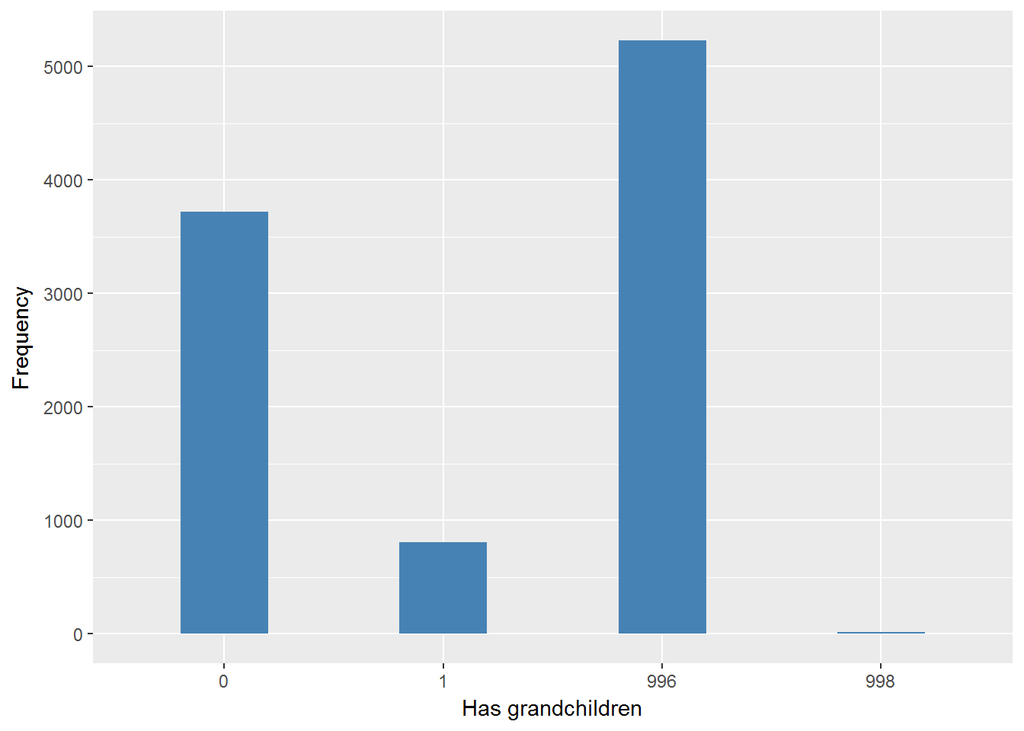

##### 2.1.3.3.1 Validation

|  | 2->0 | 1 | -9->995 | -1->996 |
| --- | --- | --- | --- | --- |
| BeforeH1 | 1091 | 7060 | 93 | 1527 |
| AfterH1 | 1091 | 7060 | 93 | 1527 |

|  | 2->0 | 1 | -1->996 | -8->998 |
| --- | --- | --- | --- | --- |
| BeforeH2 | 3718 | 806 | 5231 | 16 |
| AfterH2 | 3718 | 806 | 5231 | 16 |

### 2.1.4 Wave 4

#### 2.1.4.1 Study-specific variable description

The study-specific variable elected to be harmonised is:

- Name: `scchd`
- Label: `Whether the respondent has any children`
- Categories:
  - `1 = Yes`
  - `2 = No`
- Missings:
  - `-9 = Not answered`
  - `-8 = Don't know`
  - `-1 = Not applicable`
- Name: `digran`
- Label: `Whether respondent has any grandchildren/greatgrandchildren`
- Categories:
  - `1 = Yes`
  - `2 = No`
- Missings:
  - `-9 = Refusal`
  - `-8 = Don't Know`
  - `-2 = Capi/Interview Error`
  - `-1 = Not applicable`
- Description:

SCCHD

| Sample size | Missing values |
| --- | --- |
| 11050 | 1838 |

Category

|  | 1 | 2 |
| --- | --- | --- |
| Frequency | 7954.00 | 1258.00 |
| Percentage | 71.98 | 11.38 |

Type of missing

|  | -9 | -8 | -1 | NA |
| --- | --- | --- | --- | --- |
| Frequency | 130.00 | 0 | 1708.00 | 0 |
| Percentage | 1.18 | 0 | 15.46 | 0 |

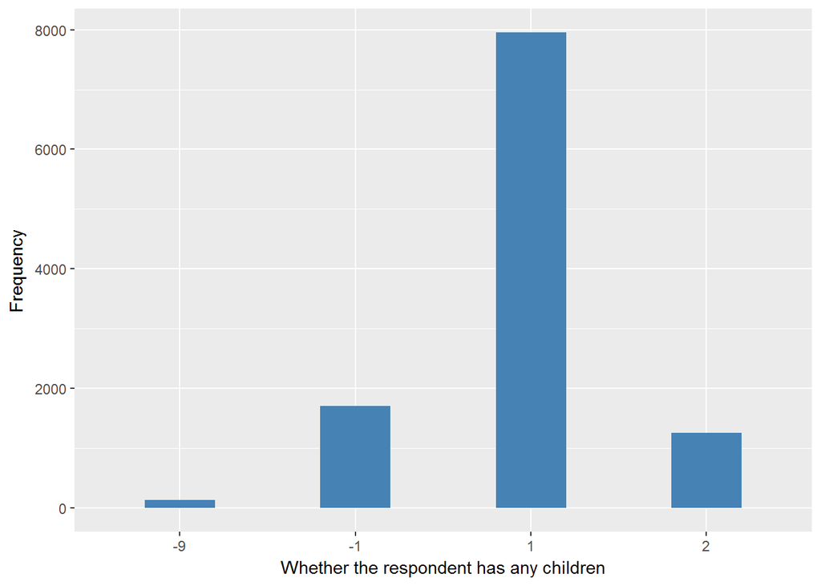

DIGRAN

| Sample size | Missing values |
| --- | --- |
| 11050 | 6528 |

Category

|  | 1 | 2 |
| --- | --- | --- |
| Frequency | 1723.00 | 2799.00 |
| Percentage | 15.59 | 25.33 |

Type of missing

|  | -9 | -8 | -2 | -1 | NA |
| --- | --- | --- | --- | --- | --- |
| Frequency | 1.00 | 16.00 | 72.00 | 6439.00 | 0 |
| Percentage | 0.01 | 0.14 | 0.65 | 58.27 | 0 |

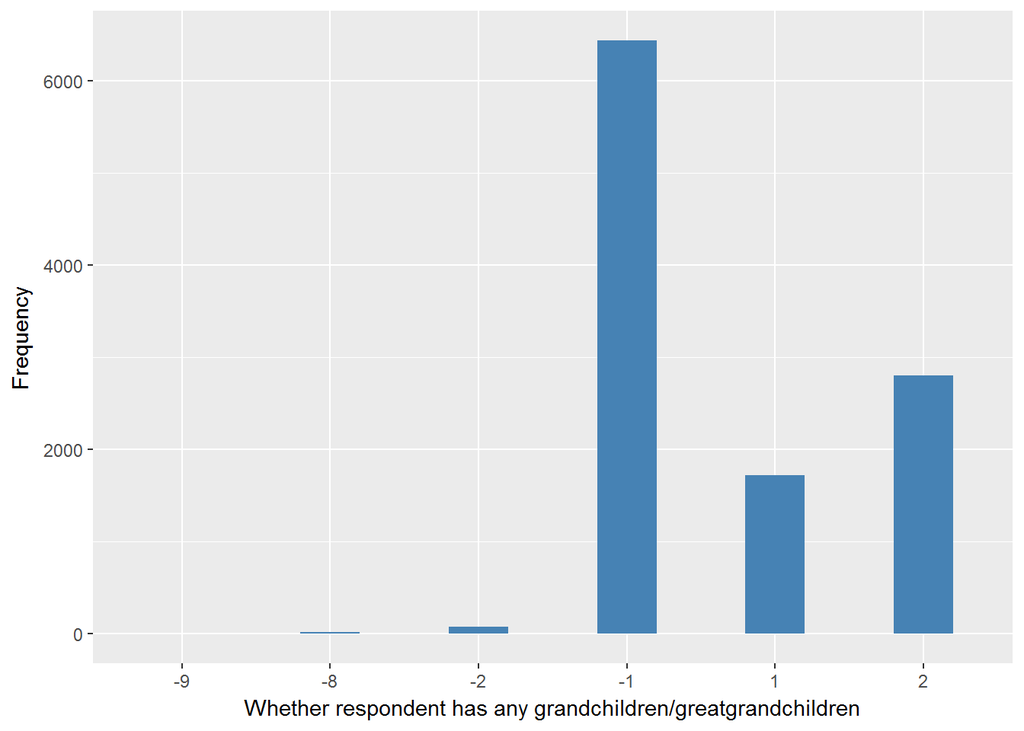

#### 2.1.4.2 Harmonisation algorithm

To recode the harmonize variable from the study-specific variable it has to be recoded as follows:

- `1 into 1`
- `2 into 0`
- `Missings for CHILD: -9 into 995; -8 into 998; -1 into 996`
- `Missings for GRCHILD: -9 into 997; -8 into 998; -2 into 991; -1 into 996`
- `NA into 999`

**R script:**

```r
ELSA_ds_w4 <- tibble(id = ELSA_w4_child$id)
ELSA_ds_w4$child <- car::recode(as.vector(ELSA_w4_child$scchd), "1='1'; 2='0'; -9='995'; -8='998'; -1='996'; NA='999'")
ELSA_ds_w4$child <- labelled(ELSA_ds_w4$child, labels = c(No = 0, Yes = 1, Missing = 999,
    `Do not know` = 998, Refuse = 997, `Not applicable` = 996, `Don't answer` = 995,
    `Not attempt/not done/not yet recorded` = 994, `Disable to measure` = 993,
    Impute = 992, `CAPI/interviewer error` = 991))

ELSA_ds_w4$grchild <- car::recode(as.vector(ELSA_w4_child$digran), "1='1'; 2='0'; -9='997'; -8='998'; -2='991'; -1='996'; NA='999'")
ELSA_ds_w4$grchild <- labelled(ELSA_ds_w4$grchild, labels = c(No = 0, Yes = 1,
    Missing = 999, `Do not know` = 998, Refuse = 997, `Not applicable` = 996,
    `Don't answer` = 995, `Not attempt/not done/not yet recorded` = 994, `Disable to measure` = 993,
    Impute = 992, `CAPI/interviewer error` = 991))
```

#### 2.1.4.3 Statistical description of the new harmonised variable

Children

| Sample size | Missing values |
| --- | --- |
| 11050 | 1838 |

Category

|  | 0 | 1 |
| --- | --- | --- |
| Frequency | 1258.00 | 7954.00 |
| Percentage | 11.38 | 71.98 |

Type of missing

|  | 991 | 992 | 993 | 994 | 995 | 996 | 997 | 998 | 999 | NA |
| --- | --- | --- | --- | --- | --- | --- | --- | --- | --- | --- |
| Frequency | 0 | 0 | 0 | 0 | 130.00 | 1708.00 | 0 | 0 | 0 | 0 |
| Percentage | 0 | 0 | 0 | 0 | 1.18 | 15.46 | 0 | 0 | 0 | 0 |

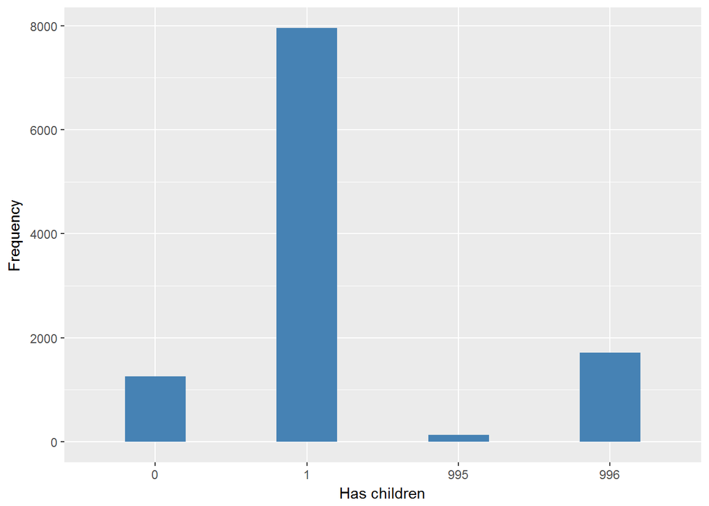

Grandchildren

| Sample size | Missing values |
| --- | --- |
| 11050 | 6528 |

Category

|  | 0 | 1 |
| --- | --- | --- |
| Frequency | 2799.00 | 1723.00 |
| Percentage | 25.33 | 15.59 |

Type of missing

|  | 991 | 992 | 993 | 994 | 995 | 996 | 997 | 998 | 999 | NA |
| --- | --- | --- | --- | --- | --- | --- | --- | --- | --- | --- |
| Frequency | 72.00 | 0 | 0 | 0 | 0 | 6439.00 | 1.00 | 16.00 | 0 | 0 |
| Percentage | 0.65 | 0 | 0 | 0 | 0 | 58.27 | 0.01 | 0.14 | 0 | 0 |

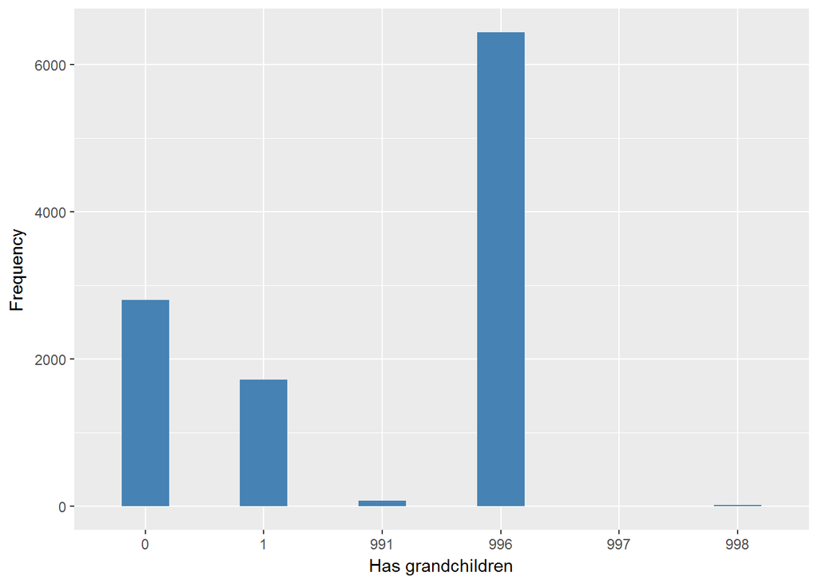

##### 2.1.4.3.1 Validation

|  | 2->0 | 1 | -9->995 | -1->996 |
| --- | --- | --- | --- | --- |
| BeforeH1 | 1258 | 7954 | 130 | 1708 |
| AfterH1 | 1258 | 7954 | 130 | 1708 |

|  | 2->0 | 1 | -2->991 | -1->996 | -9->997 | -8->998 |
| --- | --- | --- | --- | --- | --- | --- |
| BeforeH2 | 2799 | 1723 | 72 | 6439 | 1 | 16 |
| AfterH2 | 2799 | 1723 | 72 | 6439 | 1 | 16 |

### 2.1.5 Wave 5

#### 2.1.5.1 Study-specific variable description

The study-specific variable elected to be harmonised is:

- Name: `scchd`
- Label: `Whether the respondent has any children`
- Categories:
  - `1 = Yes`
  - `2 = No`
- Missings:
  - `-9 = Not answered`
  - `-8 = Don't know`
  - `-2 = Schedule Not Applicable`
  - `-1 = Item not applicable`
- Name: `digran`
- Label: `Whether respondent has any grandchildren/greatgrandchildren`
- Categories:
  - `1 = Yes`
  - `2 = No`
- Missings:
  - `-9 = Refusal`
  - `-8 = Don't Know`
  - `-2 = Schedule Not Applicable`
  - `-1 = Item not applicable`
- Description:

SCCHD

| Sample size | Missing values |
| --- | --- |
| 10274 | 1352 |

Category

|  | 1 | 2 |
| --- | --- | --- |
| Frequency | 7698.00 | 1224.00 |
| Percentage | 74.93 | 11.91 |

Type of missing

|  | -9 | -8 | -2 | -1 | NA |
| --- | --- | --- | --- | --- | --- |
| Frequency | 108.00 | 0 | 1244.00 | 0 | 0 |
| Percentage | 1.05 | 0 | 12.11 | 0 | 0 |

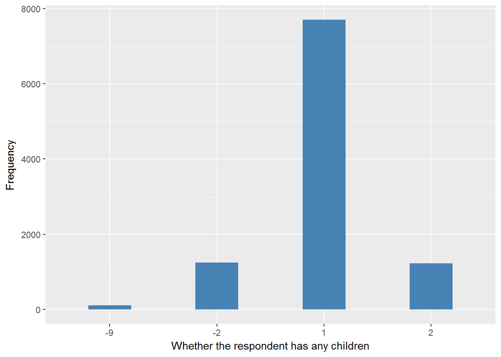

DIGRAN

| Sample size | Missing values |
| --- | --- |
| 10274 | 7439 |

Category

|  | 1 | 2 |
| --- | --- | --- |
| Frequency | 640.00 | 2195.00 |
| Percentage | 6.23 | 21.36 |

Type of missing

|  | -9 | -8 | -2 | -1 | NA |
| --- | --- | --- | --- | --- | --- |
| Frequency | 2.00 | 13.00 | 0 | 7424.00 | 0 |
| Percentage | 0.02 | 0.13 | 0 | 72.26 | 0 |

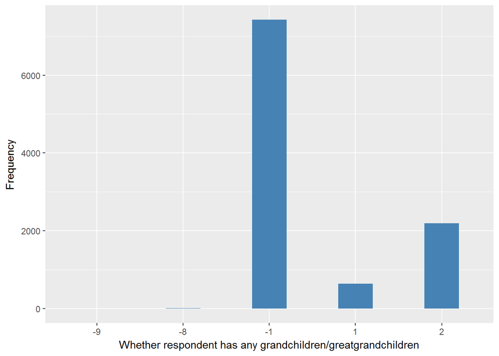

#### 2.1.5.2 Harmonisation algorithm

To recode the harmonize variable from the study-specific variable it has to be recoded as follows:

- `1 into 1`
- `2 into 0`
- `Missings for CHILD: -9 into 995; -8 into 998; -2 into 996; -1 into 996`
- `Missings for GRCHILD: -9 into 997; -8 into 998; -2 into 996; -1 into 996`
- `NA into 999`

**R script:**

```r
ELSA_ds_w5 <- tibble(id = ELSA_w5_child$id)
ELSA_ds_w5$child <- car::recode(as.vector(ELSA_w5_child$scchd), "1='1'; 2='0'; -9='995'; -8='998'; -2='996'; -1='996'; NA='999'")
ELSA_ds_w5$child <- labelled(ELSA_ds_w5$child, labels = c(No = 0, Yes = 1, Missing = 999,
    `Do not know` = 998, Refuse = 997, `Not applicable` = 996, `Don't answer` = 995,
    `Not attempt/not done/not yet recorded` = 994, `Disable to measure` = 993,
    Impute = 992, `CAPI/interviewer error` = 991))

ELSA_ds_w5$grchild <- car::recode(as.vector(ELSA_w5_child$digran), "1='1'; 2='0'; -9='997'; -8='998'; -2='996'; -1='996'; NA='999'")
ELSA_ds_w5$grchild <- labelled(ELSA_ds_w5$grchild, labels = c(No = 0, Yes = 1,
    Missing = 999, `Do not know` = 998, Refuse = 997, `Not applicable` = 996,
    `Don't answer` = 995, `Not attempt/not done/not yet recorded` = 994, `Disable to measure` = 993,
    Impute = 992, `CAPI/interviewer error` = 991))
```

#### 2.1.5.3 Statistical description of the new harmonised variable

Children

| Sample size | Missing values |
| --- | --- |
| 10274 | 1352 |

Category

|  | 0 | 1 |
| --- | --- | --- |
| Frequency | 1224.00 | 7698.00 |
| Percentage | 11.91 | 74.93 |

Type of missing

|  | 991 | 992 | 993 | 994 | 995 | 996 | 997 | 998 | 999 | NA |
| --- | --- | --- | --- | --- | --- | --- | --- | --- | --- | --- |
| Frequency | 0 | 0 | 0 | 0 | 108.00 | 1244.00 | 0 | 0 | 0 | 0 |
| Percentage | 0 | 0 | 0 | 0 | 1.05 | 12.11 | 0 | 0 | 0 | 0 |

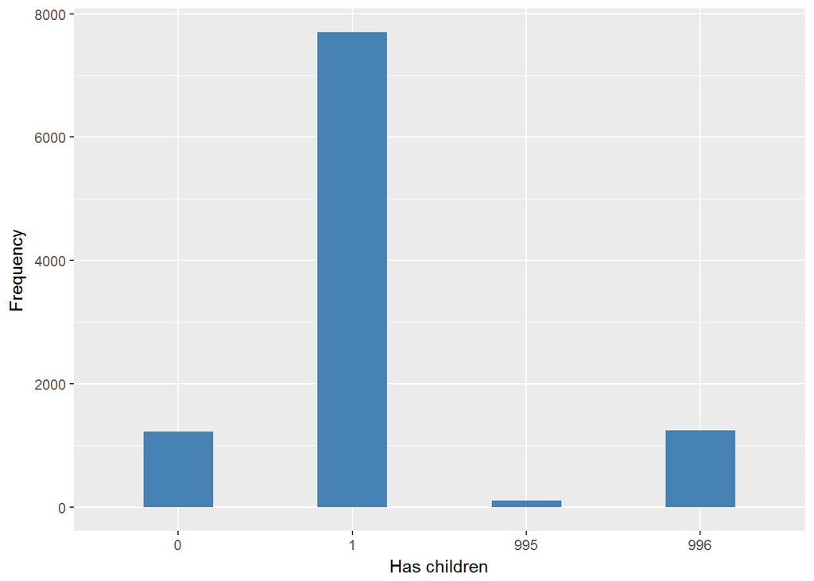

Grandchildren

| Sample size | Missing values |
| --- | --- |
| 10274 | 7439 |

Category

|  | 0 | 1 |
| --- | --- | --- |
| Frequency | 2195.00 | 640.00 |
| Percentage | 21.36 | 6.23 |

Type of missing

|  | 991 | 992 | 993 | 994 | 995 | 996 | 997 | 998 | 999 | NA |
| --- | --- | --- | --- | --- | --- | --- | --- | --- | --- | --- |
| Frequency | 0 | 0 | 0 | 0 | 0 | 7424.00 | 2.00 | 13.00 | 0 | 0 |
| Percentage | 0 | 0 | 0 | 0 | 0 | 72.26 | 0.02 | 0.13 | 0 | 0 |

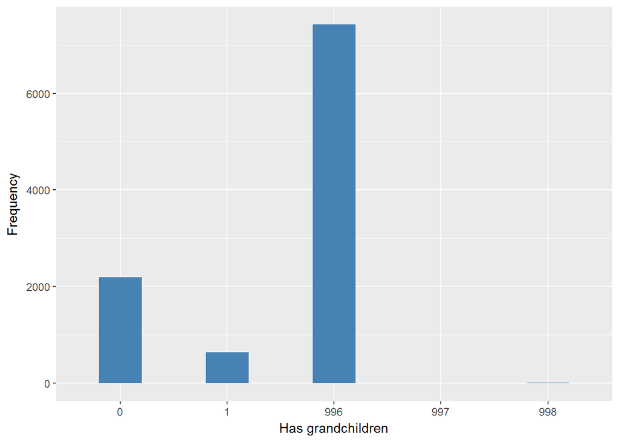

##### 2.1.5.3.1 Validation

|  | 2->0 | 1 | -9->995 | -2->996 |
| --- | --- | --- | --- | --- |
| BeforeH1 | 1224 | 7698 | 108 | 1244 |
| AfterH1 | 1224 | 7698 | 108 | 1244 |

|  | 2->0 | 1 | -1->996 | -9->997 | -8->998 |
| --- | --- | --- | --- | --- | --- |
| BeforeH2 | 2195 | 640 | 7424 | 2 | 13 |
| AfterH2 | 2195 | 640 | 7424 | 2 | 13 |

### 2.1.6 Wave 6

#### 2.1.6.1 Study-specific variable description

The study-specific variable elected to be harmonised is:

- Name: `scchd`
- Label: `Whether the respondent has any children`
- Categories:
  - `1 = Yes`
  - `2 = No`
- Missings:
  - `-9 = Not answered`
  - `-8 = Don't know`
  - `-2 = Schedule Not Applicable`
  - `-1 = Item not applicable`
- Name: `DiGran`
- Label: `Whether respondent has any grandchildren/greatgrandchildren`
- Categories:
  - `1 = Yes`
  - `2 = No`
- Missings:
  - `-9 = Refusal`
  - `-8 = Don't Know`
  - `-2 = Schedule Not Applicable`
  - `-1 = Item not applicable`
- Description:

SCCHD

| Sample size | Missing values |
| --- | --- |
| 10601 | 1638 |

Category

|  | 1 | 2 |
| --- | --- | --- |
| Frequency | 7704.00 | 1259.00 |
| Percentage | 72.67 | 11.88 |

Type of missing

|  | -9 | -8 | -2 | -1 | NA |
| --- | --- | --- | --- | --- | --- |
| Frequency | 34.00 | 0 | 1604.00 | 0 | 0 |
| Percentage | 0.32 | 0 | 15.13 | 0 | 0 |

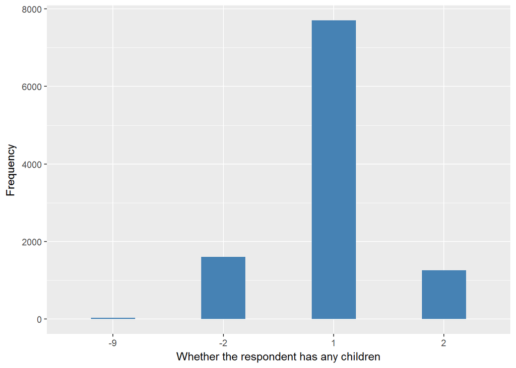

DIGRAN

| Sample size | Missing values |
| --- | --- |
| 10601 | 7387 |

Category

|  | 1 | 2 |
| --- | --- | --- |
| Frequency | 805.00 | 2409.00 |
| Percentage | 7.59 | 22.72 |

Type of missing

|  | -9 | -8 | -2 | -1 | NA |
| --- | --- | --- | --- | --- | --- |
| Frequency | 1.00 | 11.0 | 0 | 7375.00 | 0 |
| Percentage | 0.01 | 0.1 | 0 | 69.57 | 0 |

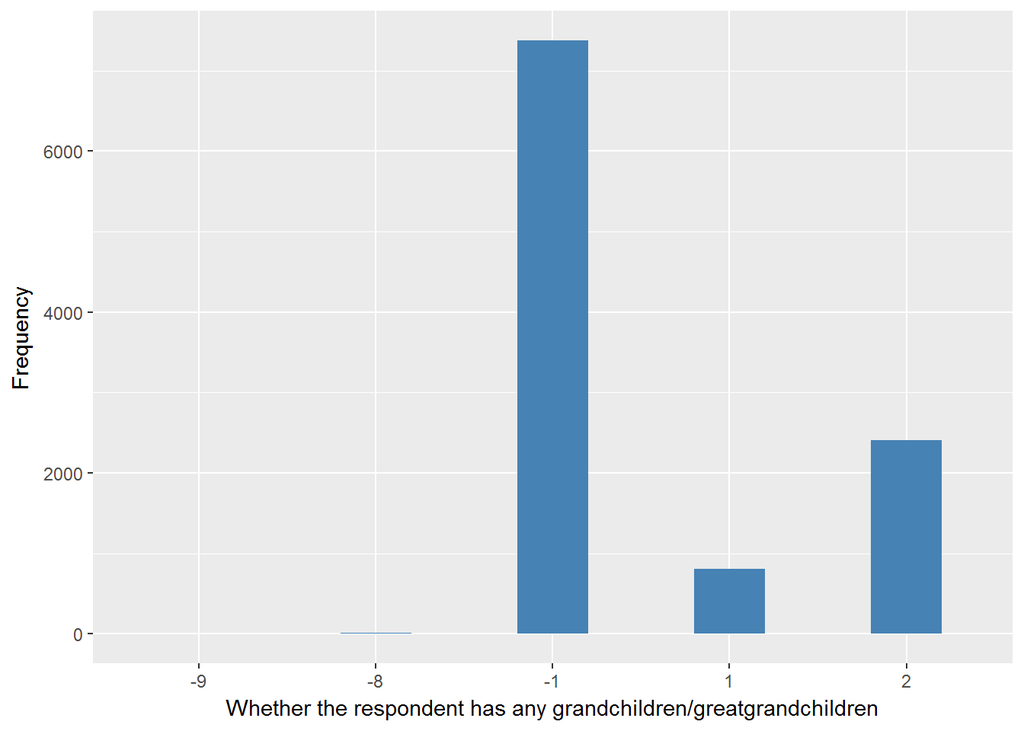

#### 2.1.6.2 Harmonisation algorithm

To recode the harmonize variable from the study-specific variable it has to be recoded as follows:

- `1 into 1`
- `2 into 0`
- `Missings for CHILD: -9 into 995; -8 into 998; -2 into 996; -1 into 996`
- `Missings for GRCHILD: -9 into 997; -8 into 998; -2 into 996; -1 into 996`
- `NA into 999`

**R script:**

```r
ELSA_ds_w6 <- tibble(id = ELSA_w6_child$id)
ELSA_ds_w6$child <- car::recode(as.vector(ELSA_w6_child$scchd), "1='1'; 2='0'; -9='995'; -8='998'; -2='996'; -1='996'; NA='999'")
ELSA_ds_w6$child <- labelled(ELSA_ds_w6$child, labels = c(No = 0, Yes = 1, Missing = 999,
    `Do not know` = 998, Refuse = 997, `Not applicable` = 996, `Don't answer` = 995,
    `Not attempt/not done/not yet recorded` = 994, `Disable to measure` = 993,
    Impute = 992, `CAPI/interviewer error` = 991))

ELSA_ds_w6$grchild <- car::recode(as.vector(ELSA_w6_child$DiGran), "1='1'; 2='0'; -9='997'; -8='998'; -2='996'; -1='996'; NA='999'")
ELSA_ds_w6$grchild <- labelled(ELSA_ds_w6$grchild, labels = c(No = 0, Yes = 1,
    Missing = 999, `Do not know` = 998, Refuse = 997, `Not applicable` = 996,
    `Don't answer` = 995, `Not attempt/not done/not yet recorded` = 994, `Disable to measure` = 993,
    Impute = 992, `CAPI/interviewer error` = 991))
```

#### 2.1.6.3 Statistical description of the new harmonised variable

Children

| Sample size | Missing values |
| --- | --- |
| 10601 | 1638 |

Category

|  | 0 | 1 |
| --- | --- | --- |
| Frequency | 1259.00 | 7704.00 |
| Percentage | 11.88 | 72.67 |

Type of missing

|  | 991 | 992 | 993 | 994 | 995 | 996 | 997 | 998 | 999 | NA |
| --- | --- | --- | --- | --- | --- | --- | --- | --- | --- | --- |
| Frequency | 0 | 0 | 0 | 0 | 34.00 | 1604.00 | 0 | 0 | 0 | 0 |
| Percentage | 0 | 0 | 0 | 0 | 0.32 | 15.13 | 0 | 0 | 0 | 0 |

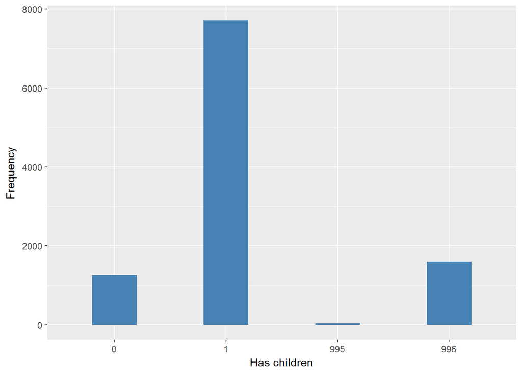

Grandchildren

| Sample size | Missing values |
| --- | --- |
| 10601 | 7387 |

Category

|  | 0 | 1 |
| --- | --- | --- |
| Frequency | 2409.00 | 805.00 |
| Percentage | 22.72 | 7.59 |

Type of missing

|  | 991 | 992 | 993 | 994 | 995 | 996 | 997 | 998 | 999 | NA |
| --- | --- | --- | --- | --- | --- | --- | --- | --- | --- | --- |
| Frequency | 0 | 0 | 0 | 0 | 0 | 7375.00 | 1.00 | 11.0 | 0 | 0 |
| Percentage | 0 | 0 | 0 | 0 | 0 | 69.57 | 0.01 | 0.1 | 0 | 0 |

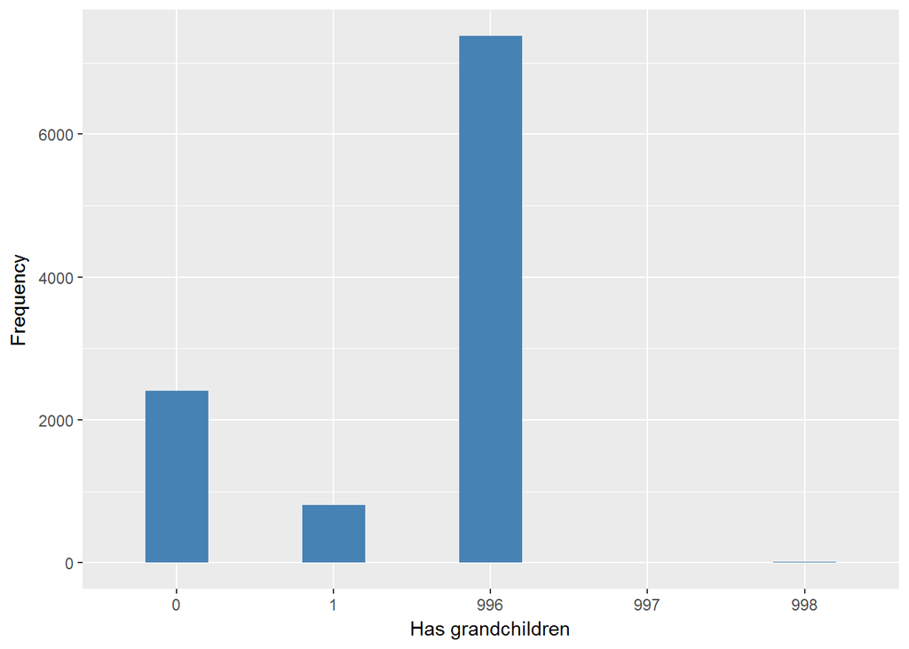

#### 2.1.6.4 Validation

|  | 2->0 | 1 | -9->995 | -2->996 |
| --- | --- | --- | --- | --- |
| BeforeH1 | 1259 | 7704 | 34 | 1604 |
| AfterH1 | 1259 | 7704 | 34 | 1604 |

|  | 2->0 | 1 | -1->996 | -9->997 | -8->998 |
| --- | --- | --- | --- | --- | --- |
| BeforeH2 | 2409 | 805 | 7375 | 1 | 11 |
| AfterH2 | 2409 | 805 | 7375 | 1 | 11 |

### 2.1.7 Wave 7

#### 2.1.7.1 Study-specific variable description

The study-specific variable elected to be harmonised is:

- Name: `scchd`
- Label: `Whether the respondent has any children`
- Categories:
  - `1 = Yes`
  - `2 = No`
- Missings:
  - `-9 = Not answered`
  - `-8 = Don't know`
  - `-2 = Schedule Not Applicable`
  - `-1 = Item not applicable`
- Name: `DiGran`
- Label: `Whether respondent has any Whether the respondent has any children`
- Categories:
  - `1 = Yes`
  - `2 = No`
- Missings:
  - `-9 = Refusal`
  - `-8 = Don't Know`
  - `-2 = Schedule Not Applicable`
  - `-1 = Item not applicable`
- Description:

| Sample size | Missing values |
| --- | --- |
| 9666 | 1521 |

Category

|  | 1 | 2 |
| --- | --- | --- |
| Frequency | 6987.00 | 1158.00 |
| Percentage | 72.28 | 11.98 |

Type of missing

|  | -9 | -8 | -2 | -1 | NA |
| --- | --- | --- | --- | --- | --- |
| Frequency | 52.00 | 0 | 1469.0 | 0 | 0 |
| Percentage | 0.54 | 0 | 15.2 | 0 | 0 |

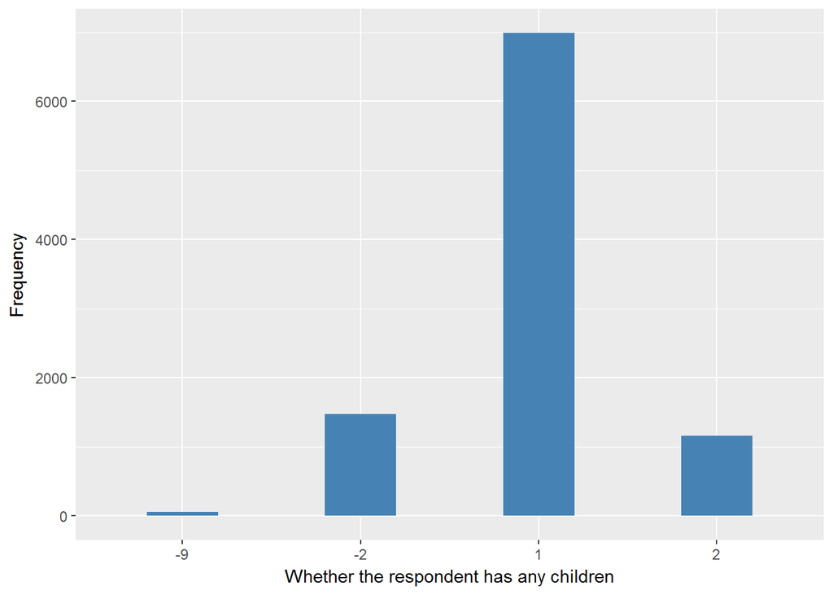

| Sample size | Missing values |
| --- | --- |
| 9666 | 6799 |

Category

|  | 1 | 2 |
| --- | --- | --- |
| Frequency | 823.00 | 2044.00 |
| Percentage | 8.51 | 21.15 |

Type of missing

|  | -9 | -8 | -2 | -1 | NA |
| --- | --- | --- | --- | --- | --- |
| Frequency | 1.00 | 9.00 | 0 | 6789.00 | 0 |
| Percentage | 0.01 | 0.09 | 0 | 70.24 | 0 |

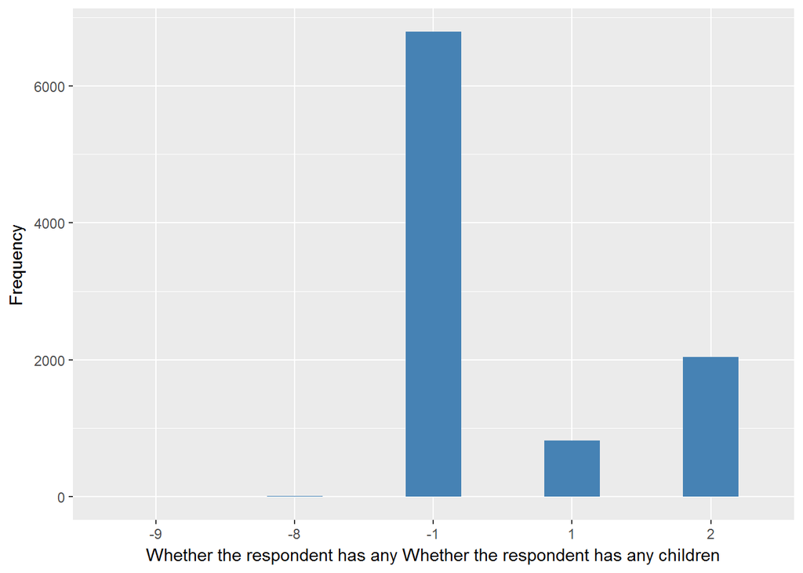

#### 2.1.7.2 Harmonisation algorithm

To recode the harmonize variable from the study-specific variable it has to be recoded as follows:

- `1 into 1`
- `2 into 0`
- `Missings for CHILD: -9 into 995; -8 into 998; -2 into 996; -1 into 996`
- `Missings for GRCHILD: -9 into 997; -8 into 998; -2 into 996; -1 into 996`
- `NA into 999`

**R script:**

```r
ELSA_ds_w7 <- tibble(id = ELSA_w7_child$id)
ELSA_ds_w7$child <- car::recode(as.vector(ELSA_w7_child$scchd), "1='1'; 2='0'; -9='995'; -8='998'; -2='996'; -1='996'; NA='999'")
ELSA_ds_w7$child <- labelled(ELSA_ds_w7$child, labels = c(No = 0, Yes = 1, Missing = 999,
    `Do not know` = 998, Refuse = 997, `Not applicable` = 996, `Don't answer` = 995,
    `Not attempt/not done/not yet recorded` = 994, `Disable to measure` = 993,
    Impute = 992, `CAPI/interviewer error` = 991))

ELSA_ds_w7$grchild <- car::recode(as.vector(ELSA_w7_child$DiGran), "1='1'; 2='0'; -9='997'; -8='998'; -2='996'; -1='996'; NA='999'")
ELSA_ds_w7$grchild <- labelled(ELSA_ds_w7$grchild, labels = c(No = 0, Yes = 1,
    Missing = 999, `Do not know` = 998, Refuse = 997, `Not applicable` = 996,
    `Don't answer` = 995, `Not attempt/not done/not yet recorded` = 994, `Disable to measure` = 993,
    Impute = 992, `CAPI/interviewer error` = 991))
```

#### 2.1.7.3 Statistical description of the new harmonised variable

Children

| Sample size | Missing values |
| --- | --- |
| 9666 | 1521 |

Category

|  | 0 | 1 |
| --- | --- | --- |
| Frequency | 1158.00 | 6987.00 |
| Percentage | 11.98 | 72.28 |

Type of missing

|  | 991 | 992 | 993 | 994 | 995 | 996 | 997 | 998 | 999 | NA |
| --- | --- | --- | --- | --- | --- | --- | --- | --- | --- | --- |
| Frequency | 0 | 0 | 0 | 0 | 52.00 | 1469.0 | 0 | 0 | 0 | 0 |
| Percentage | 0 | 0 | 0 | 0 | 0.54 | 15.2 | 0 | 0 | 0 | 0 |

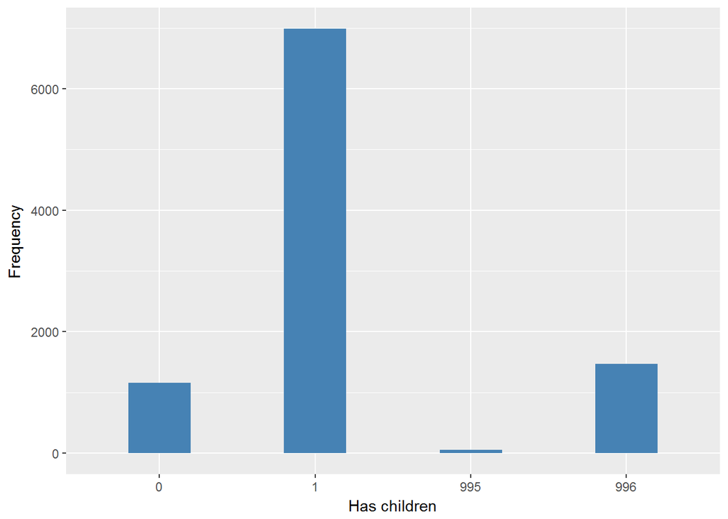

Grandchildren

| Sample size | Missing values |
| --- | --- |
| 9666 | 6799 |

Category

|  | 0 | 1 |
| --- | --- | --- |
| Frequency | 2044.00 | 823.00 |
| Percentage | 21.15 | 8.51 |

Type of missing

|  | 991 | 992 | 993 | 994 | 995 | 996 | 997 | 998 | 999 | NA |
| --- | --- | --- | --- | --- | --- | --- | --- | --- | --- | --- |
| Frequency | 0 | 0 | 0 | 0 | 0 | 6789.00 | 1.00 | 9.00 | 0 | 0 |
| Percentage | 0 | 0 | 0 | 0 | 0 | 70.24 | 0.01 | 0.09 | 0 | 0 |

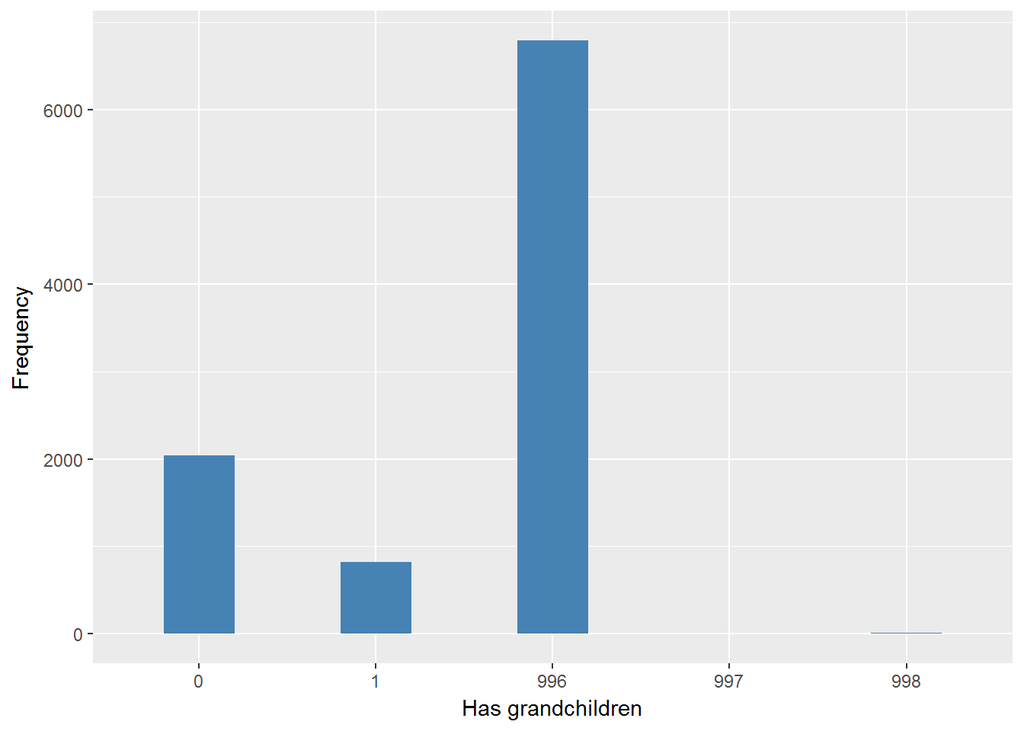

#### 2.1.7.4 Validation

[output not shown]

|  | 2->0 | 1 | -1->996 | -9->997 | -8->998 |
| --- | --- | --- | --- | --- | --- |
| BeforeH2 | 2044 | 823 | 6789 | 1 | 9 |
| AfterH2 | 2044 | 823 | 6789 | 1 | 9 |

# 3 Quality estimation